# Monte Carlo

Nathan Hart

6/8/2021

## R Markdown

### Summary:

Three options for dealing with SO2 pollution: 1. no scrubber 2. wet scrubber 3. dry scrubber

dry scrubber can be turned on and off dynamically at no cost. A threshold must be determined for switching on/off.

### Parameters

Writing down all of the constants or estimates in the case here so they are easy to reference and adjust as needed.

```r
#financial params
quarter.discount.rate <- 0.02411
wet.initial.investment.percent <- 0.75

#pricing params
ea.price.per.ton <- 1150 #to play around with for direct calculation
ea.initial.ppt <- 800 #initial value. will simulate with random walk, expected to increase
drift <- 0.0125
sd.error <- 0.06
num.quarters <- 60 #15 years of quarterly price changes

#emissions data
emissions.per.quarter <- 4000
EA.allocation <- 2000
discount.rate <- 0.1

#wet scrubber params
#estimated value, but up to 99% possible
wet.scrub.efficiency <- 0.98
#cost per ton of SO2 processed
wet.cost.per.ton <- 10
#120M to install system
wet.investment <- 120000000
#unit is fiscal quarters, 3-5 but 10% chance of less than one year. 20% chance of more than a year
wet.install.time.quarters <- 4

#dry scrubber params
dry.investment <- 5000000
dry.install.time.quarters <- 1 #estimate
dry.var.cost.per.ton <- 600
dry.scrub.efficiency <- 0.55 #40%-70% is range, choosing 55 as described by prof
dry.on.threshold <- 600

#import csv coal data
coal.data <- read.csv(file.choose(), header=TRUE, sep=",", stringsAsFactors = TRUE)
```

### Direct Calculations

Not doing any simulation here, just calculating using average or estimated values.

From case: “I can compare the scrubbers at $1150 EA cost”

```r
#no scrubs
total.cost.none <- (emissions.per.quarter - EA.allocation) * ea.price.per.ton
print(total.cost.none)
```

```
## [1] 2300000
```

```r
#wet scrubber
wet.emissions <- emissions.per.quarter * (1-wet.scrub.efficiency)
total.cost.wet <- (wet.emissions - EA.allocation) * ea.price.per.ton #negative numbers are earnings
print(total.cost.wet)
```

```
## [1] -2208000
```

```r
#dry scrubber
dry.emissions <- emissions.per.quarter * (1 - dry.scrub.efficiency)
operating.cost.dry <- emissions.per.quarter * dry.var.cost.per.ton
total.cost.dry <- (dry.emissions - EA.allocation) * ea.price.per.ton + operating.cost.dry
print(total.cost.dry)
```

```
## [1] 2170000
```

### Simulation setup

Monte Carlo simulations for uncertain variables

Random walk simulation for prices https://nwfsc-timeseries.github.io/atsa-labs/sec-tslab-random-walks-rw.html

Vectors of payoffs, npv function from FinCal library to calculate NPV

functions for calculating emissions and npv of each solution. factoring in on/off decisions, build time, build costs and pay timings

```r
#parameter number of times to simulate
num.sims <- 1000

#random walk function for EA prices
random.walk.ea <- function(seed){
  ## set random number seed
  set.seed(seed)
  ## initialize arrays. unclear if SD error needs to be multiplied by initial value or not
  prices.sim <- noise <- rnorm(n = num.quarters, mean = drift * ea.initial.ppt, sd = sd.error * ea.initial.ppt)
  ## compute values 2 thru TT
  prices.sim[1] <- ea.initial.ppt
  for (t in 2:num.quarters) {
    #look at last value, add a deviation (gaussian noise)
    #could also add drift here multiplied by most recent value if we are looking for more an exponential drift?
      prices.sim[t] <- (prices.sim[t - 1] + noise[t])
  }
  return(prices.sim)
}

#no scrubber npv calculation function
no.scrub.npv <- function(simulated.prices){
  no.scrub.payoffs <- (emissions.per.quarter - EA.allocation) * simulated.prices
  no.scrub.cost <- npv(quarter.discount.rate, no.scrub.payoffs)
  return(no.scrub.cost)
}

#wet scrubber npv calc function
wet.scrub.npv <- function(simulated.prices){
  wet.emissions <- emissions.per.quarter * (1-wet.scrub.efficiency)
  wet.payoffs <- (wet.emissions - EA.allocation) * simulated.prices
  #don't get emissions benefits until operational, no scrub emissions until then
  wet.payoffs[1:wet.install.time.quarters] <- (emissions.per.quarter - EA.allocation) * simulated.prices[1:wet.install.time.quarters]
  #TODO may be off by one below, might need a initial cost before first quarter. will be close either way
  wet.payoffs[1] <- wet.payoffs[1] + wet.initial.investment.percent * wet.investment
  wet.payoffs[wet.install.time.quarters] <- wet.payoffs[wet.install.time.quarters] + (1-wet.initial.investment.percent) * wet.investment
  wet.total.cost <- npv(quarter.discount.rate, wet.payoffs) #negative numbers are earnings
  return(wet.total.cost)
}

wet.scrub.npv(random.walk.ea(123))
```

```
## [1] 61337880
```

```r
#dry scrubber npv calculation function
dry.scrub.npv <- function(simulated.prices, threshold.ea.price){
  #excess emissions when turned on
  dry.emissions <- (emissions.per.quarter - EA.allocation) * (1 - dry.scrub.efficiency)
  off.emissions <- emissions.per.quarter - EA.allocation
  #vector with emissions based on on/off threshold
  real.excess.emissions <- ifelse(simulated.prices > threshold.ea.price, dry.emissions, off.emissions)
  #print(real.excess.emissions)
  #vector with costs per quarter factoring in on/off decision
  dry.payoffs <- real.excess.emissions * simulated.prices
  #don't get emissions benefits until operational, no scrub emissions until then
  dry.payoffs[1:dry.install.time.quarters] <- off.emissions * simulated.prices[1:dry.install.time.quarters]
  #initial investment to build system
  dry.payoffs[1] <- dry.payoffs[1] + dry.investment
  #variable cost, not counting time under construction
  dry.payoffs[dry.install.time.quarters:num.quarters] <- ifelse(simulated.prices[dry.install.time.quarters:num.quarters] > threshold.ea.price, dry.payoffs[dry.install.time.quarters:num.quarters] + dry.var.cost.per.ton * real.excess.emissions[dry.install.time.quarters:num.quarters], dry.payoffs[dry.install.time.quarters:num.quarters])
  #npv of dry scrubber project
  dry.total.cost <- npv(quarter.discount.rate, dry.payoffs)
  #print(dry.payoffs)
  return(dry.total.cost)
  #TODO: factor in different coal types, terminal value for npv?
}

dry.scrub.npv(random.walk.ea(123), dry.on.threshold)
```

```
## [1] 55839698
```

```r
#calculate total emissions from dry scrub solution
dry.scrub.emissions <- function(simulated.prices){

}


sim.data <- data.frame(
  id = c(1:num.sims),
  no.scrubber.npv = c(0),
  wet.scrubber.npv = c(0),
  dry.scrubber.npv = c(0),
  dry.scrubber.emissions = c(0)

  )

#show data table for next section, plus output from random walk algorithm
head(sim.data)
```

```
##   id no.scrubber.npv wet.scrubber.npv dry.scrubber.npv dry.scrubber.emissions
## 1  1               0                0                0                      0
## 2  2               0                0                0                      0
## 3  3               0                0                0                      0
## 4  4               0                0                0                      0
## 5  5               0                0                0                      0
## 6  6               0                0                0                      0
```

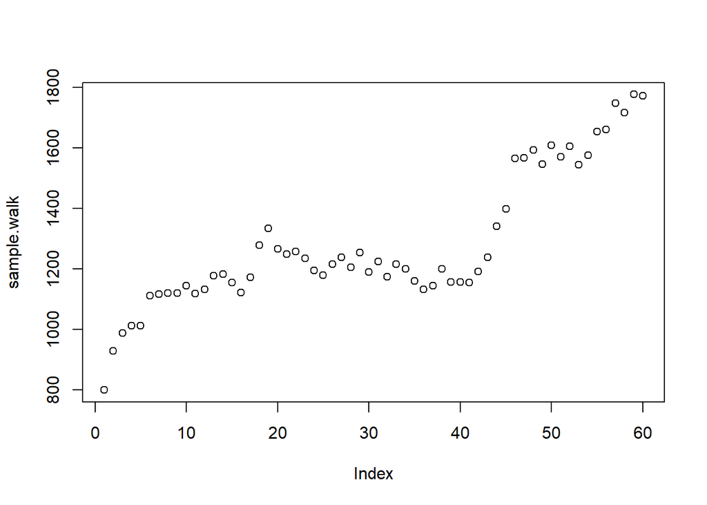

```r
sample.walk <- random.walk.ea(22)
plot(sample.walk)
```

```r
#wet.scrub.npv(sample.walk)
```

### Simulation

Simulation iterations set above, will create many different EA price profiles to get distribution of outcomes

Emissions for no scrubber and wet scrubber are constant

For dry scrubber: type of coal will have impact on efficiency. Emissions will vary based on price and threshold chosen

Note: positive numbers are costs, as that is more or less the “default” scenario

Format output to make profit/loss clear

```r
for (i in 1:num.sims) {
  #use index as new seed to get many possible EA price curves
  prices.sim <- random.walk.ea(i)

  #no scrubber
  sim.data$no.scrubber.npv[i] <- no.scrub.npv(prices.sim)

  #wet scrubber
  sim.data$wet.scrubber.npv[i] <- wet.scrub.npv(prices.sim)

  #dry scrubber
  sim.data$dry.scrubber.npv[i] <- dry.scrub.npv(prices.sim, dry.on.threshold)

  #emissions will vary now in addition to costs/savings

}

#no scrub emissions, assuming emissions are constant, implied in case
no.scrub.emissions <- (emissions.per.quarter - EA.allocation) * num.quarters
#print(no.scrub.emissions)

#wet emissions assuming constant emissions
total.emissions.wet <- (wet.emissions - EA.allocation) * num.quarters
#print(total.emissions.wet)

head(sim.data)
```

```
##   id no.scrubber.npv wet.scrubber.npv dry.scrubber.npv dry.scrubber.emissions
## 1  1        76240179         57152578         57633221                      0
## 2  2        79819709         54098724         59244010                      0
## 3  3        59100655         73256961         49920435                      0
## 4  4        92439037         41648015         64922707                      0
## 5  5        70714199         62687830         55146530                      0
## 6  6        74802479         58722206         56986256                      0
```

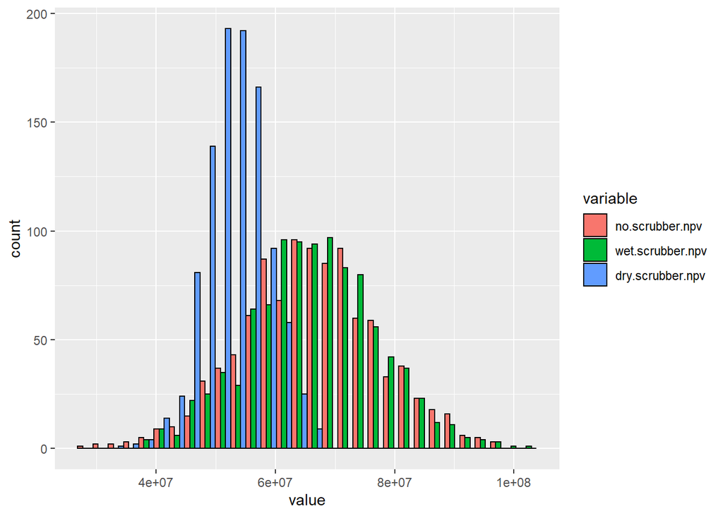

```r
plot.data <- melt(sim.data[,2:4])
#View(plot.data)
ggplot(plot.data, aes(x=value, fill = variable), alpha = 0.5) + geom_histogram(position = 'dodge', color = "black")
```

### Optimization

Loop through different values of threshold for the dry scrubber to determine optimal threshold.

Ideas: make a 95% confidence interval for EA prices and use those curves

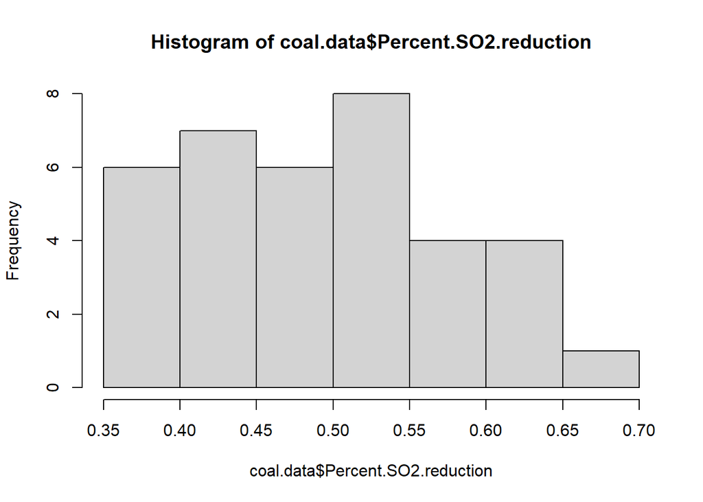

```r
thresholds <- seq(500, 1000, 10)
efficiencies <- seq(40,60,5)
opt.sim.count <- 50

optimization.data <- data.frame(threshold.values = thresholds, npv = c(0), efficiency.values = c(0))
eff.optimization.data <- data.frame()

hist(coal.data$Percent.SO2.reduction)
```

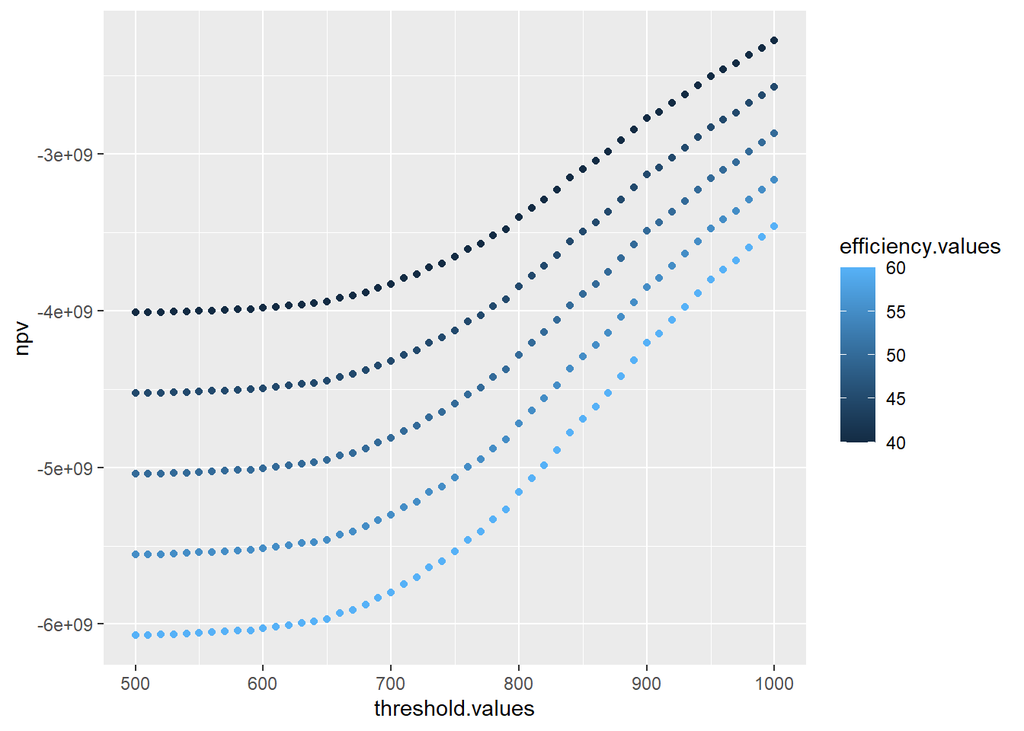

```r
#TODO factor in prediction error: make an error vector as an argument to npv function


#TODO: make efficiency a parameter to dry scrub npv function
for(dry.scrub.efficiency in efficiencies){
  for(threshold in thresholds){
    npv.vec <- vector(mode = "numeric", length = opt.sim.count)
    for(i in 0:(opt.sim.count-1)){
      prices.sim <- random.walk.ea(i)
      #simulate 60 quarters
      npv.vec[i] <- dry.scrub.npv(prices.sim, threshold)
    }
    #average of each simulation
    optimization.data$npv[optimization.data$threshold.values == threshold] <- mean(npv.vec)
    #organized by efficiency level
    optimization.data$efficiency.values[optimization.data$threshold.values == threshold] <- dry.scrub.efficiency
  }
  #append new data for different efficiency level
  eff.optimization.data <- rbind(eff.optimization.data, optimization.data)
}


ggplot(eff.optimization.data, aes(x=threshold.values, y=npv, color=efficiency.values)) + geom_point()
```

```r
#View(optimization.data)
```